# Methodological Detail Appendix: Tighter Nets for Smaller Fishes? Mapping the Development of Statistical Practices in Consumer Research Between 2008 and 2020

Antonia Krefeld-Schwalb and Benjamin Scheibehenne

29 January, 2022

The following skript runs all analyses reported in the manuscript “Tighter Nets for Smaller Fishes? Mapping the Development of Statistical Practices in Consumer Research Between 2008 and 2020”.

To re-run the analyses make sure that the required packages are installed and the data files ‘Data.csv’ with all text-mined coded manuscripts, ‘Datahandcoded.csv’ with all handcoded articles are in your working directory.

The effect sizes of the F, $\omega^2$, and t-test, d, were transformed to the commmon r-scale, to be analyzed and plotted together.

### Number of studies, co-authors and proportion of field studies

|  | JCP | JCR | JMR |
| --- | --- | --- | --- |
| Nostudies | 2.02 | 3.00 | 2.15 |
| NoCoauthors | 1.74 | 1.39 | 1.84 |
| PR(Field Studies) | 0.09 | 0.10 | 0.24 |

|  | 8 | 9 | 10 | 11 | 12 | 13 | 14 | 15 | 16 | 17 | 18 | 19 | 20 |
| --- | --- | --- | --- | --- | --- | --- | --- | --- | --- | --- | --- | --- | --- |
| Nostudies | 1.41 | 2.56 | 1.93 | 2.50 | 1.91 | 2.57 | 1.75 | 1.39 | 2.81 | 3.29 | 3.88 | 2.88 | 3.62 |
| NoCoauthors | 1.35 | 1.50 | 1.67 | 1.45 | 1.71 | 1.68 | 1.48 | 1.44 | 2.00 | 1.88 | 1.35 | 2.06 | 1.94 |
| PR(Field Studies) | 0.06 | 0.19 | 0.07 | 0.08 | 0.00 | 0.04 | 0.07 | 0.09 | 0.19 | 0.41 | 0.29 | 0.38 | 0.31 |

### Sample size per cell

Calculation of the sample size for the F-test:

Assuming that most of the test compare independent groups we approximated the sample sizes via $N = df_2 + df_1 +1$ K = Number of groups $df_1 = K-1$ $df_2 = N-K$

Calculation of the sample size for the t-test: As for the F-tests we assumed that most of the studies represent manipulations between subjects. Thus we approximated the total sample size with the df of the t-tests: $N = df +2$

The sample size per cell can next be estimated by dividing the total sample size with the number of conditions (k).

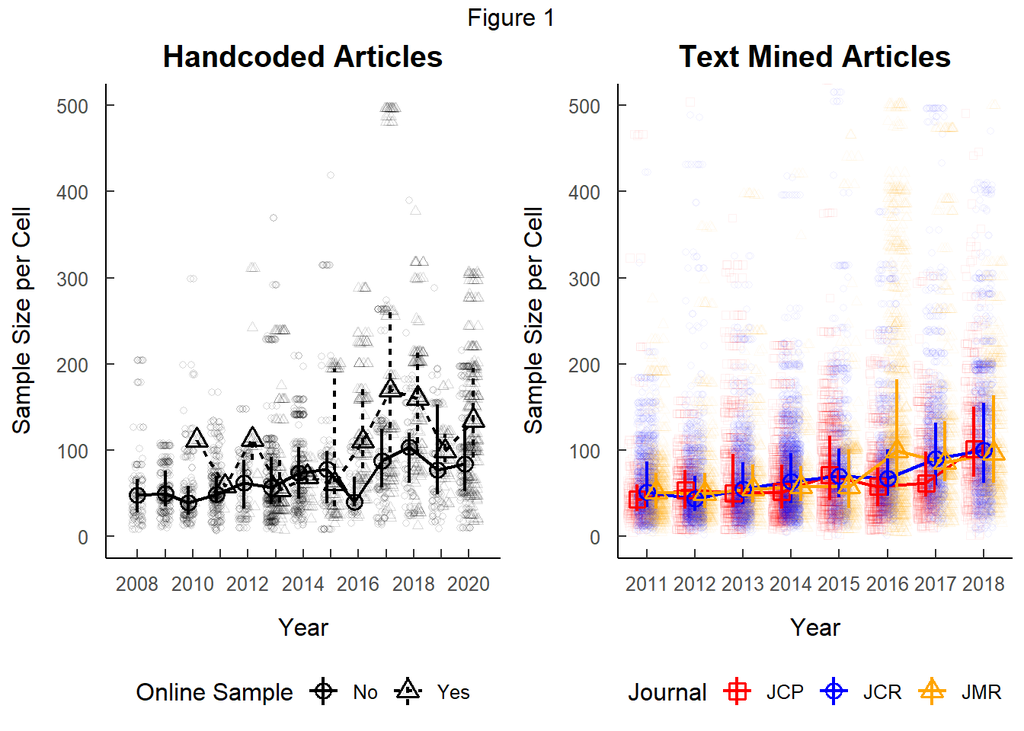

|  | logNpc |  |  |
| --- | --- | --- | --- |
| Predictors | Estimates | CI | p |
| (Intercept) | 2.98 | 2.69 – 3.28 | **<0.001** |
| Year | 0.05 | 0.03 – 0.07 | **<0.001** |
| Mturk | 0.40 | 0.34 – 0.47 | **<0.001** |
| Random Effects |  |  |  |
| σ<sup>2</sup> | 0.27 |  |  |
| τ<sub>00</sub> <sub>Article</sub> | 0.19 |  |  |
| ICC | 0.41 |  |  |
| N <sub>Article</sub> | 154 |  |  |
| Observations | 3427 |  |  |
| Marginal R<sup>2</sup> / Conditional R<sup>2</sup> | 0.165 / 0.505 |  |  |

### Effect size (r)

The effect sizes of the F, $\omega^2$, and t-test, d, were transformed to the commmon r-scale, to be analyzed and plotted together.

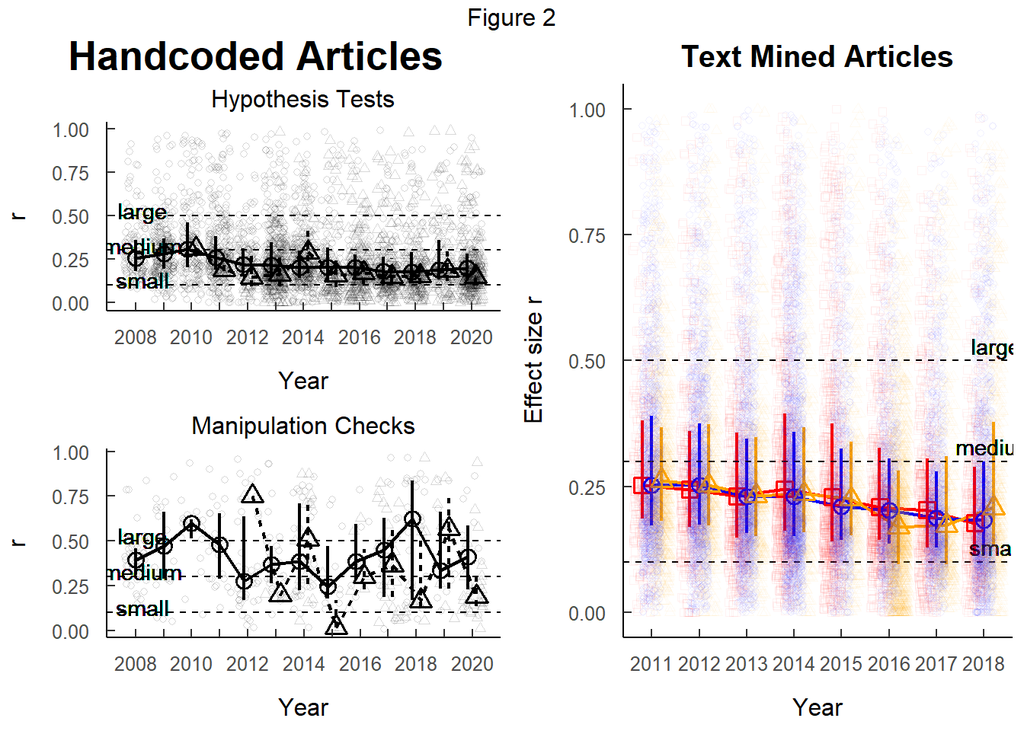

|  | logr |  |  |
| --- | --- | --- | --- |
| Predictors | Estimates | CI | p |
| (Intercept) | -0.64 | -1.05 – -0.23 | **0.002** |
| Year | -0.05 | -0.07 – -0.02 | **0.002** |
| Mturk [2] | -0.19 | -0.34 – -0.03 | **0.019** |
| Random Effects |  |  |  |
| σ<sup>2</sup> | 1.87 |  |  |
| τ<sub>00</sub> <sub>Article</sub> | 0.27 |  |  |
| ICC | 0.13 |  |  |
| N <sub>Article</sub> | 154 |  |  |
| Observations | 3235 |  |  |
| Marginal R<sup>2</sup> / Conditional R<sup>2</sup> | 0.021 / 0.144 |  |  |

|  | logr |  |  |
| --- | --- | --- | --- |
| Predictors | Estimates | CI | p |
| (Intercept) | 0.97 | 0.53 – 1.42 | **<0.001** |
| Year | -0.02 | -0.04 – 0.01 | 0.269 |
| Mturk [2] | -0.02 | -0.17 – 0.13 | 0.781 |
| logNpc | -0.50 | -0.57 – -0.42 | **<0.001** |
| Random Effects |  |  |  |
| σ<sup>2</sup> | 1.78 |  |  |
| τ<sub>00</sub> <sub>Article</sub> | 0.21 |  |  |
| ICC | 0.11 |  |  |
| N <sub>Article</sub> | 154 |  |  |
| Observations | 3235 |  |  |
| Marginal R<sup>2</sup> / Conditional R<sup>2</sup> | 0.087 / 0.183 |  |  |

### P-value distirbution and z-curve analysis

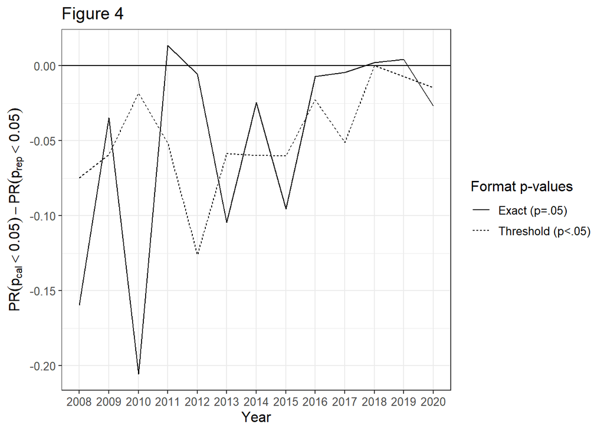

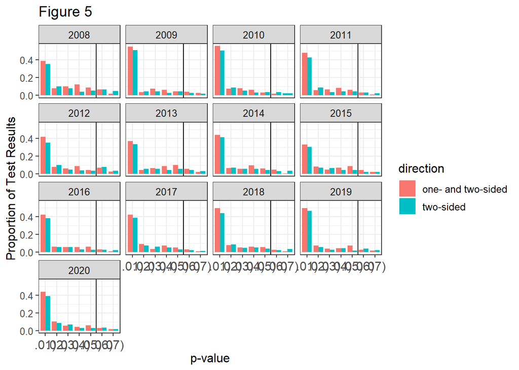

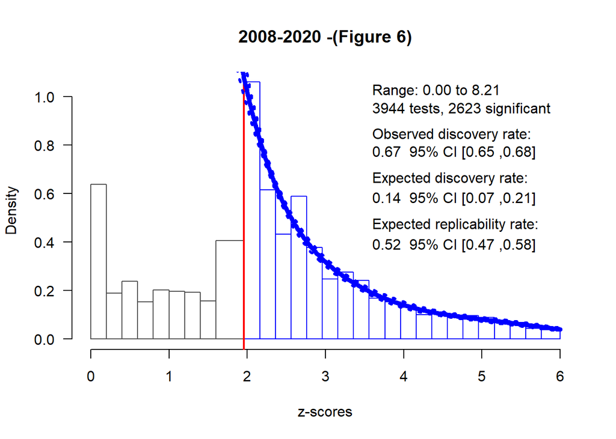

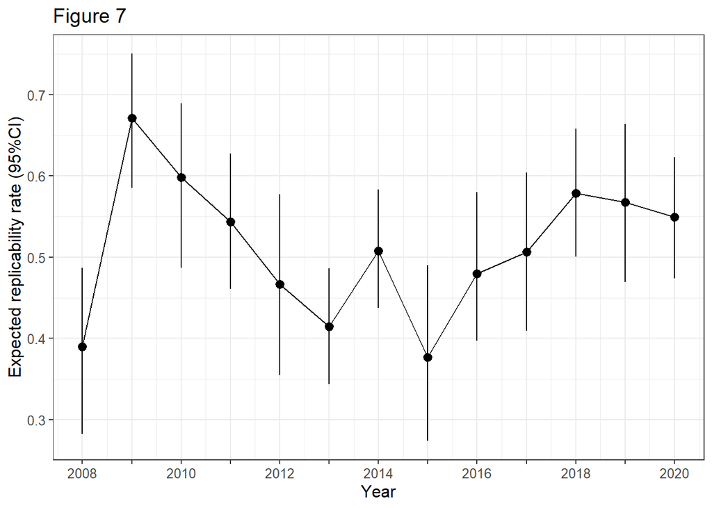